# HAPR linear

We have electronic health records on potential cardiac patients. The patients are followed for 10 years. We observe disease status (ASCVD) and a polygenic score. We also have covariates: PREVENT score (a standard risk estimate based on traditional risk factors) and gender.

```r
head(heart_disease_data)
```

```
## # A tibble: 6 × 4
##   prob_ascvd polygenic_score prevent_score gender
##        <dbl>           <dbl>         <dbl> <fct>
## 1     0.0155          -0.983        0.0428 female
## 2     0.0489          -0.797        0.181  male
## 3     0.262            0.749        0.0814 female
## 4     0.0649          -0.562        0.0147 male
## 5     0.0170          -0.894        0.0238 male
## 6     0.0424           0.577        0.0153 female
```

We want to estimate the clinical utility of the polygenic score. And to estimate how this clinical utility is expected to improve as the polygenic score becomes more predictive. The current polygenic score is based on a GWAS with $R^2$ of 2%, whereas the estimated heritability of ASCVD is around 20%. HAPR combines these heritability estimates with the current correlations to estimate a model of the future polygenic score.

The main estimation function is `hapr()`.

```r
library(hapr)

covariates <- heart_disease_data |> select(prevent_score, gender) # Covariates

hapr_fit <- hapr(
  y = heart_disease_data$prob_ascvd, # Outcome
  gc = heart_disease_data$polygenic_score, # Polygenic score
  w = covariates, # Covariates
  model_type = "lm",
  r2_current = 0.02, # Current R-squared of the polygenic score
  r2_future = 0.2 # Future R-squared of the polygenic score, estimate of heritability
)

print(hapr_fit)
```

```
## 🐵  HAPR (Heritability Adjusted Prediction) Model  🐵
## -------------------------------------------
## Model type: lm
##
## Beta coefficients (future PRS effects):
##               Estimate
## (Intercept)   0.002597
## gf            0.333791
## prevent_score 0.988423
## gendermale    0.040284
##
## Improvement ratio: 10.0000 ( r2_future )
## R² current: 0.0200 ( user_provided )
## R² future: 0.2000
## Max improvement ratio: 4573.9453
```

It is intuitive to see what is going on if we simulate the full model with the true polygenic score:

```r
simulated_data <- hapr_simulate(hapr_fit, covariates)

head(simulated_data)
```

```
##            gf         gc prevent_score gender
## 1 -0.02515233 -0.7847887    0.04275714 female
## 2  0.28570724  1.0489747    0.18114824   male
## 3 -0.44245079  0.9341225    0.08136762 female
## 4 -0.23651199  0.5212903    0.01474663   male
## 5  0.16450267  0.3702956    0.02379530   male
## 6  0.22968682  0.1642303    0.01532521 female
```

```r
risk_dataset <- predict(hapr_fit, simulated_data)

head(risk_dataset)
```

```
##            gf         gc prevent_score gender    y_hat_w y_hat_gc_w  y_hat_gf_w
## 1 -0.02515233 -0.7847887    0.04275714 female 0.05975569 0.03212494  0.03646329
## 2  0.28570724  1.0489747    0.18114824   male 0.21813095 0.25345524  0.31729846
## 3 -0.44245079  0.9341225    0.08136762 female 0.10193037 0.13116212 -0.06466381
## 4 -0.23651199  0.5212903    0.01474663   male 0.03636853 0.05583917 -0.02148891
## 5  0.16450267  0.3702956    0.02379530   male 0.04625250 0.06059916  0.12131019
## 6  0.22968682  0.1642303    0.01532521 female 0.02979148 0.03406024  0.09441203
```

We can now compare how the current and future polygenic scores add value relative to the traditional risk factors. One simple way are scatterplots of the predicted risk using the polygenic score vs the predicted risk using the traditional risk factors. If the polygenic score adds little extra value, we should see the points clustered around the diagonal.

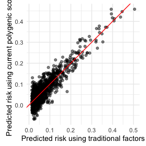

```r
# Plot for current polygenic score
ggplot(risk_dataset, aes(x = y_hat_w, y = y_hat_gc_w)) +
  geom_point(alpha = 0.5) +
  geom_abline(slope = 1, intercept = 0, color = "red") +
  coord_fixed(ratio = 1) +  # Ensures 1:1 aspect ratio
  theme_minimal() +
  labs(x = "Predicted risk using traditional factors",
       y = "Predicted risk using current polygenic score")
```

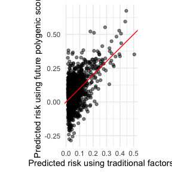

```r
# Plot for future polygenic score
ggplot(risk_dataset, aes(x = y_hat_w, y = y_hat_gf_w)) +
  geom_point(alpha = 0.5) +
  geom_abline(slope = 1, intercept = 0, color = "red") +
  coord_fixed(ratio = 1) +  # Ensures 1:1 aspect ratio
  theme_minimal() +
  labs(x = "Predicted risk using traditional factors",
       y = "Predicted risk using future polygenic score")
```